# The first seizure, a monocentric study

Version: V3

# Data dictionary

1. **database**: The data acquisition was done in two steps, this variable specifies to which of the steps the data point belongs, type character
2. **ordre**: Order in which the patients were entered in the database, type numeric
3. **code.pat**: code attributed to each patient, type character
4. **age**: Patient’s age, type numeric
5. **genre**: Patient’s gender, type character
6. **atcd.enfance**: Relevant medical history of the patient during his childhood, type character
7. **atcd.famille**: Relevant medical history of the patient’s close family, type character
8. **date.1st.EEG**: Date of the first standard EEG after the index event, type Date (lubridate)
9. **res.1st.EEG**: Result of the first EEG (normal, abnormal, none, none but proposed), type character
10. **pointes.1st.EEG**: Presence of epileptic spikes on the standard EEG (focal, generalised, NA), type character
11. **slow.1st.EEG**: Presence of a slowing or non-epileptic abnormalities on the standard EEG (focal, generalised, NA), type character
12. **tt.1st.EEG**: Drugs active during the standard EEG that could have reduce the spike detection (none, BZD, AED, antidepressant, neuroleptics, other, none/other, NA), type character
13. **res.lt.EEG**: Result of the first long-term EEG (normal, abnormal, none, none but proposed), type character
14. **pointes.lt.EEG**: Presence of epileptic spikes on the LT EEG (focal, generalised, NA), type character
15. **slow.lt.EEG**: Presence of a slowing or non-epileptic abnormalities on the LT EEG (focal, generalised, NA), type character
16. **tt.lt.EEG**: Drugs active during the LT EEG that could have reduce the spike detection (none, BZD, AED, antidepressant, neuroleptics, other, none/other, NA), type character
17. **normal.1st.lt.EEG**: Combination of the normality information of the standard and LT EEG, type character
18. **date.CT**: Date of the realisation of the first CT after the index event, type Date(lubridate)
19. **res.CT**: Result of the brain CT (normal, abnormal, none, none but proposed). abnromal CT contain all types of abnormalities: epileptogenic or not, type character
20. **les.CT**: Type of abnormalities (dementia, vascular, tumor, malformation, unknown, none, NA), type = character
21. **res.IRM**: Result of the brain MRI (normal, abnormal, none, none but proposed). abnromal MRI contain all types of abnormalities: epileptogenic or not, type character
22. **date.IRM**: date of the first MRI after first event, type Date (lubridate) 23.**les.IRM**: Type of abnormalities (dementia, vascular, tumor, malformation, unknown, none, NA), type = character
23. **les.epi**: Combined information of CT and MRI specifying if the lesion is epileptogenic, non-epileptogenic, suspicious, or normal
24. **date.1st.cs.su**: Date of the first consultation to the emergency department (ED) after the index event, type POSIXct
25. **date.1st.cs.epi**: Date of the first consultation in the epileptology unit of the HUG, type POSIXct
26. **dx.final**: Final diagnosis (Acute symptomatic seizure (crise provoquee), unknown, cardiovascular origin, psychogenic, other, epilepsy (crise epilepsie) vaso-vagal syncopes, cardiac origin, cardiac) retained after 2 years follow-up (for patients for whom the follow-up information was available), type character
27. **type.epi.final**: For patients with dx.final == crise epilepsie, specification of the epilepsy type (NA, non-lesional, idiopathic generalised (IGE), unknown), type character
28. **dx.final.margitta**: Correction of the diagnosis a posteriori by MS, type character
29. **cat.dx.final**: To be removed, type logical
30. **resident**: to understand why patients were lost in follow-up, infromation of where the patients are living (TRUE = Geneva’s area, FALSE = other canton or country), type logical
31. **veille.sommeil**: Did the event happened during sleep or wake time, type character
32. **status.neuro**: Results of the neuro status (normal, abnormal, none, none but proposed), type character
33. **commentaire**: Brief description of the cases in french, type character
34. **n.ret.SU**: Number of times a patient came back to the ED for a relapse, type numeric
35. **n.recidives.rapp**: Number of reported relapses in consultations, type numeric
36. **n.tot.recidives**: Number of total relapses combining reported and ED consultations, type numeric
37. **type.resident**: Description if the patient lives in another canton, country, had the first seizure while traveling…, type character
38. **SBB.1**: Number of seizures before the index event (1 = first seizure, 2 = one seizure before the index event, 3 = more than one seizure before the index event), type = numeric
39. **SBB.2**: Trajectory of the patients after the ED (1 = hospitalisation, 2 = ambulatory cares or lost, 4 = hospitalisation but with an admission in the intensive care unit before), type = numeric
40. **SBB.3**: Trajectory of patients after the ED (1 = hospitalisation in epileptology, 2 = hospitalisation in neurology, 3 = hospitalised in the intensive care unit and lost, 4 = hospitalised in neurosurgery, 5 = hospitalised in psychiatry, 6 = hospitalised in another service, 7 = specialised ambulatory cares, 8 = followed outside the hospital or lost), type numeric
41. **SBB.4**: Long term follow-up information for patients with SBB.3 = 7 (1 = other specialised follow-up, 2 = epileptology, 3 = neurology, 4 = neurosurgery, 5 = psychatry), type = numeric
42. **SBB.5**: Trajectory of patients followed-up in epileptology
43. follow-up of 12 to 24 months
44. follow-up by a private neurologist after a 3 months follow-up in the epileptology unit
45. follow-up by the neurology service after a 3 months follow-up in the epileptology unit
46. follow-up of 3 to 6 months in the epileptology unit and then stop because not needed
47. follow-up of 3 to 6 months in the epileptology unit and then followed-up by a private neurologist
48. follow-up of 6 to 12 months in the epileptology unit and then follow-up not needed anymore
49. follow-up of 6 to 12 months in the epileptology unit and then followed-up by a private neurologist
50. follow-up of 6 to 12 months in the epileptology unit and then followed-up by another service
51. follow-up of 3 to 6 months in the epileptology unit and then followed-up by another service
52. follow-up by the neurosurgery service after a 3 months follow-up in the epileptology unit
53. follow-up by another service after a 3 months follow-up in the epileptology unit
54. 3 months follow-up in the epileptology unit and then lost
55. 3 months follow-up in the epileptology unit and then follow-up not needed anymore
56. follow-up of 3 to 6 months in the epileptology unit and then patient lost
57. follow-up of 3 to 6 months in the epileptology unit and then follow-up not needed
58. follow-up of 6 to 12 months in the epileptology unit and then patient lost
59. follow-up of 6 to 12 months in the epileptology unit and then follow-up not needed
60. after a follow-up of 12 to 24 months in epileptology, follow-up scheduled
61. after a follow-up of 12 to 24 months in epileptology, patient lost
62. after a follow-up of 12 to 24 months in epileptology, follow-up not needed
63. Follow-up in epileptology at 3 months and then the patient deceased
64. Follow-up in epileptology at 3 to 6 months and then the patient deceased
65. Follow-up in epileptology at 6 to 12 months and then the patient deceased
66. Follow-up in epileptology at 12 to 24 months and then the patient deceased
67. **doute.critere**: Patients for whom the inclusion criteria have been discussed, type logical
68. **date.1st.1st.sz**: Date of the first event event before the index event, type Date (lubridate)
69. **date.2nd.1st.sz**: Date of an eventual second event before the index event, type POSIXct
70. **date.dern.1st.sz**: In case of more than 2 seizures before the index event, date of the last event before the index one, type POSIXct
71. **date.adm.si**: Date of hospitalisation in the intensive care unit, type POSIXct
72. **date.sortie.si**: Date of the end of hospitalisation in the intensive care unit, type Date (lubridate)
73. **date.1st.cs.neuro**: Date of the first consultation in the neurology service, type POSIXct
74. **date.dern.cs.neuro**: Date of the last consultation in the neurology service, type POSIXct
75. **raison_stop_suivi.neuro**: Motive of the interruption of follow-up by the neurology service, type character
76. **date.1st.cs.neurochir**: Date of the first consultation in the neurosurgery service, type POSIXct
77. **date.dern.cs.neurochir**: Date of the last consultation in the neurosurgery service, type POSIXct
78. **raison_stop_suivi.neurochir**: Motive of the interruption of follow-up by the neurosurgery service, type character
79. **date.1st.cs.psy**: Date of the first consultation in the psychiatry service, type POSIXct
80. **date.dern.cs.psy**: Date of the last consultation in the psychiatry service, type POSIXct
81. **raison_stop_suivi.psy**: Motive of the interruption of follow-up by the psychiatry service, type character
82. **date.1st.cs.autre**: Date of the first consultation in another service, type POSIXct
83. **date.dern.cs.autre**: Date of the last consultation in anothers ervice, type POSIXct
84. **raison_stop_suivi.autre**: Motive of the interruption of follow-up by another service, type character
85. **type_suivi.autre**: By which other service the patient was followed-up, type character
86. **date.dern.cs.epi**: Date of the last consultation in the epileptology unit, type POSIXct
87. **date.entree.1st.hospit**: Date of hospitalisation of the patient, type POSIXct
88. **srv.1st.hospit.si_autre**: If SBB.3 = 6, in which service the patient was hospitalised, type character
89. **date.debut.tt**: Date at which the anti-epileptic drug was prescribed, type POSIXct
90. **date.fin.tt**: Date of the end of treatment, type POSIXct
91. **date.dx.final**: Date at which the final diagnosis was announced to the patient, type Date (lubridate)
92. **date.deces**: Date of decease, type POSIXct
93. **cause.deces**: Origin of the death, type character
94. **date.entree.2nd.hospit**: In case of a second hospitalisation after the seizure (seizure –> emergency dept. –> hospitalisation –> 2nd hospitalisation), date of entry in the service, type POSIXct
95. **date.sortie.2nd.hospit**: In case of a second hospitalisation after the first seizure, date of release from the hospital, type POSIXct
96. **srv.2nd.hospit**: Medical service in which the second hospitalisation took place, type character
97. **type.1st.sz**: type of the first seizure (secondary generalized seizures; focals, generalized, acute symptomatic, unknown), type character
98. **type.principal.seizure**: Main type of seizure experienced by a patient, type character
99. **dx.initial**: diagnosis proposed after the first consultation, type character
100. **type.epi.initial**: Epilepsy type proposed after the first consultation, type character
101. **type.autre.initial**: For patients who recieved the diagnosis other, specification of the origin of the episode after the first consultation, type character
102. **type.autre.final**: For patients who recieved the diagnosis other, specification of the origin of the episode after 2 years follow-up, type character
103. **type.cardiovasculaire**: For the patients who recived the diagnosis of cardiovascular origin to their first event, description of the type of cardiovascular disease, type character
104. **date.sortie.1st.hospit**: Date of release after the first hospitalisation, type POSIXct
105. **review.dx**: Patients for whom the diagnosis needed a review, irrelevant column, type logical
106. **AED**: Is the patient under anti-epileptic drug ? type logical
107. **EEG.result_resume**: Summary column groupping the information of the different modalities of pointes.1st.EEG and slow.1st.EEG, type character
108. **EEG.lt.result_resume**: Summary column groupping the information of the different modalities of pointes.lt.EEG and slow.lt.EEG, type character
109. **operated**: Has the patient been operated ? type logical
110. **ATCD_specific**: Description of the medical history before the first event, type character
111. **les.progressive**: For patients who showed a brain lesion, specification if the lesion was progressive or not, type character
112. **type_EGI**: For patients with generalized epilepsy, specification of the type of generalized epilepsy, type character
113. **dx.general**: Reformulation of the column dx.final (Epileptic seizure, non-epileptic event, unknown), type character
114. **dx.event**: Reformulation of the column dx.final (Acute syptomatic seizure, Epilepsy, cardiovascular…), type character
115. **dx.epi**: Reformulation of the column dx.final and type.epi.final (focal vs. generalized), type character

# Method

```r
# Not the first event
tot_pat <- nrow(data_full_cleaned%>%filter(!is.na(code.pat)))
N_not_first_event <- nrow(data_full_cleaned%>%filter(SBB.1 > 1))
pct_not_first_event <- pct.fun(nrow(data_full_cleaned%>%filter(SBB.1 > 1)), nrow(data_full_cleaned%>%filter(!is.na(code.pat))))

# N patients admited in the ED
N_pat_adm_ED <- nrow(data_full_cleaned%>%filter(!is.na(date.1st.cs.su)))

pct_pat_adm_ED <- pct.fun(nrow(data_full_cleaned%>%filter(!is.na(date.1st.cs.su))), nrow(data_full_cleaned%>%filter(!is.na(code.pat))))
```

In 7.41% (N = 75/1012) detailed patient history showed that the index event was not the first one. Most of the patients were admitted in the ED (90.81%; N = 919/1012), the remainder on the ward outside the neurology clinic.

```r
# Delay EEG

N_EEG_24h <- nrow(data_full_cleaned%>%
  mutate(delay_EEG = date.1st.EEG - date.1st.cs.su)%>%
  select(delay_EEG)%>%
  filter(delay_EEG < 2))

N_EEG <- nrow(data_full_cleaned%>%filter(!is.na(res.1st.EEG)))

pct_N_EEG_24h <- pct.fun(N_EEG_24h, N_EEG)

# N CT
N_CT <- nrow(data_full_cleaned%>%
  filter(res.CT != "aucun" & res.CT != "aucun mais propose"))

pct_CT <- pct.fun(N_CT, tot_pat)

# Delays
delays <- data_full_cleaned%>%filter(res.IRM != "aucun" & res.IRM != "aucun mais propose")%>%
  filter(res.lt.EEG != "aucun" & res.lt.EEG != "aucun mais propose")%>%
  mutate(delay_mri = as.numeric(date.IRM - date.1st.cs.su),
         delay_lt_eeg = as.numeric(date.lt.EEG - date.1st.cs.su))%>%
  filter(delay_mri >= 0 | delay_lt_eeg >= 0)%>%
  select(delay_mri, delay_lt_eeg, date.IRM, date.lt.EEG, date.1st.cs.su)%>%
  summarise(median_delay_mri = median(delay_mri, na.rm = T),
            median_delay_lt_eeg= median(delay_lt_eeg, na.rm = T))
```

For all patients, routine EEG within 24 h was organized, and obtained in 68.68% (N = 695/1012) of the cases. CT was carried out in 79.05% (N = 800/1012) of the cases. As an effect of our preliminary analysis of the yield of long-term EEG (LT-EEG) and MRI from the study of Fisch et al (JOON), both exams were often already organized by the colleague in the ED and obtained on median within 37 and 8 days, respectively.

# Results

```r
# N female patients
N_fem <- nrow(data_full_cleaned[data_full_cleaned$genre == "F",])

# Mean age
M_SD_age <- data_full_cleaned%>%summarise(M_age = round(mean(age),1),
                                          SD_age = round(sd(age),1))
#range age
range_age <- range(data_full_cleaned$age)

# N patients with epileptic seizure
N_epi_sz <- data_full_cleaned%>%
  filter(dx.general == "Epileptic seizure")%>%
  summarise(N_epi_sz = n(),
            pct_epi_sz = pct.fun(N_epi_sz, tot_pat))

# N patients acute symptomatic seizure

tot_epi_sz <- nrow(data_full_cleaned[data_full_cleaned$dx.general == "Epileptic seizure",])

N_acute <- data_full_cleaned%>%
  filter(dx.event == "Acute symptomatic seizure")%>%
   summarise(N_acute = n(),
            pct_acute_tot = pct.fun(N_acute, tot_pat),
            pct_acute_epi = pct.fun(N_acute, tot_epi_sz))

# cause non-epileptic nature
non_epi <- data_full_cleaned%>%
  filter(dx.general == "Non epileptic event")%>%
  summarise(N_non_epi = n(),
            pct_non_epi = pct.fun(N_non_epi, tot_pat))

# N pat_per dx
tot_non_epi <- nrow(data_full_cleaned%>%filter(dx.event != "Epilepsy" | is.na(dx.event)))

N_dx_event <- data_full_cleaned%>%
  group_by(dx.event)%>%
  summarise(N = n(),
            pct_tot = pct.fun(N,tot_pat),
            pct_non_epi = pct.fun(N,tot_non_epi))
```

**Distribution of the diagnoses in the tree**

```r
##-----------------------------------------------------------------------
##  Creation of the summary tables for each step of the diagnostic tree
##-----------------------------------------------------------------------

# first step

data_full_cleaned%>%
  summarise(N = n(), age.pat = mean(age), sd = sd(age))
```

```
## # A tibble: 1 x 3
##       N age.pat    sd
##   <int>   <dbl> <dbl>
## 1  1012    53.8  22.1
```

```r
data_full_cleaned%>% group_by(genre)%>%
  summarise(N = n(), age.pat = mean(age), sd = sd(age))
```

```
## # A tibble: 2 x 4
##   genre     N age.pat    sd
##   <chr> <int>   <dbl> <dbl>
## 1 F       441    55.8  22.1
## 2 H       571    52.2  21.9
```

```r
# second step

data_full_cleaned%>%
  group_by(dx.general)%>%
  summarise(N = n(), age.pat = mean(age), sd = sd(age))
```

```
## # A tibble: 3 x 4
##   dx.general              N age.pat    sd
##   <chr>               <int>   <dbl> <dbl>
## 1 Epileptic seizure     582    54.1  21.6
## 2 Non epileptic event   354    53.6  22.9
## 3 Unknown                76    52.6  21.8
```

```r
data_full_cleaned%>% group_by(dx.general, genre)%>%
  summarise(N = n(), age.pat = mean(age), sd = sd(age))
```

```
## # A tibble: 6 x 5
## # Groups:   dx.general [3]
##   dx.general          genre     N age.pat    sd
##   <chr>               <chr> <int>   <dbl> <dbl>
## 1 Epileptic seizure   F       222    57.5  21.5
## 2 Epileptic seizure   H       360    52.0  21.5
## 3 Non epileptic event F       183    53.8  23.2
## 4 Non epileptic event H       171    53.4  22.6
## 5 Unknown             F        36    56.2  19.9
## 6 Unknown             H        40    49.3  23.2
```

```r
# Third step

data_full_cleaned%>%
  group_by(dx.general,dx.event)%>%
  summarise(N = n(), age.pat = mean(age), sd = sd(age))
```

```
## # A tibble: 9 x 5
## # Groups:   dx.general [3]
##   dx.general          dx.event                                N age.pat    sd
##   <chr>               <chr>                               <int>   <dbl> <dbl>
## 1 Epileptic seizure   Acute symptomatic seizure              41    49.7  21.7
## 2 Epileptic seizure   Epilepsy                              473    55.2  21.4
## 3 Epileptic seizure   Unknown                                68    48.9  22.3
## 4 Non epileptic event Cardiac                                13    71.8  17.5
## 5 Non epileptic event Cardiovascular                        102    61.8  23.6
## 6 Non epileptic event Other                                 139    55.0  21.5
## 7 Non epileptic event Psychogenic non epileptic seizure      62    38.9  17.4
## 8 Non epileptic event Vaso-vagal and orthostatic syncopes    38    44.4  19.5
## 9 Unknown             <NA>                                   76    52.6  21.8
```

```r
data_full_cleaned%>%
  group_by(dx.general,dx.event, genre)%>%
  summarise(N = n(), age.pat = mean(age), sd = sd(age))
```

```
## # A tibble: 18 x 6
## # Groups:   dx.general, dx.event [9]
##    dx.general         dx.event                         genre     N age.pat    sd
##    <chr>              <chr>                            <chr> <int>   <dbl> <dbl>
##  1 Epileptic seizure  Acute symptomatic seizure        F        12    56.8 24.8
##  2 Epileptic seizure  Acute symptomatic seizure        H        29    46.8 20.0
##  3 Epileptic seizure  Epilepsy                         F       185    58.7 21.0
##  4 Epileptic seizure  Epilepsy                         H       288    53.0 21.5
##  5 Epileptic seizure  Unknown                          F        25    48.9 22.4
##  6 Epileptic seizure  Unknown                          H        43    48.8 22.4
##  7 Non epileptic eve~ Cardiac                          F         6    80.3  6.12
##  8 Non epileptic eve~ Cardiac                          H         7    64.6 21.1
##  9 Non epileptic eve~ Cardiovascular                   F        51    61.0 25.6
## 10 Non epileptic eve~ Cardiovascular                   H        51    62.6 21.8
## 11 Non epileptic eve~ Other                            F        74    54.7 21.7
## 12 Non epileptic eve~ Other                            H        65    55.2 21.4
## 13 Non epileptic eve~ Psychogenic non epileptic seizu~ F        35    40.2 16.6
## 14 Non epileptic eve~ Psychogenic non epileptic seizu~ H        27    37.2 18.7
## 15 Non epileptic eve~ Vaso-vagal and orthostatic sync~ F        17    46.8 21.0
## 16 Non epileptic eve~ Vaso-vagal and orthostatic sync~ H        21    42.5 18.5
## 17 Unknown            <NA>                             F        36    56.2 19.9
## 18 Unknown            <NA>                             H        40    49.3 23.2
```

```r
# Fourth step

data_full_cleaned%>%
  group_by(dx.event, dx.epi)%>%
  summarise(N = n(), age.pat = mean(age), sd = sd(age))
```

```
## # A tibble: 10 x 5
## # Groups:   dx.event [9]
##    dx.event                         dx.epi                       N age.pat    sd
##    <chr>                            <chr>                    <int>   <dbl> <dbl>
##  1 Acute symptomatic seizure        <NA>                        41    49.7  21.7
##  2 Cardiac                          <NA>                        13    71.8  17.5
##  3 Cardiovascular                   <NA>                       102    61.8  23.6
##  4 Epilepsy                         Focal epilepsy             441    57.4  20.4
##  5 Epilepsy                         Primary generalized epi~    32    26.0  10.7
##  6 Other                            <NA>                       139    55.0  21.5
##  7 Psychogenic non epileptic seizu~ <NA>                        62    38.9  17.4
##  8 Unknown                          <NA>                        68    48.9  22.3
##  9 Vaso-vagal and orthostatic sync~ <NA>                        38    44.4  19.5
## 10 <NA>                             <NA>                        76    52.6  21.8
```

```r
data_full_cleaned%>%
  group_by(dx.event, dx.epi, genre)%>%
  summarise(N = n(), age.pat = mean(age), sd = sd(age))
```

```
## # A tibble: 20 x 6
## # Groups:   dx.event, dx.epi [10]
##    dx.event                     dx.epi                 genre     N age.pat    sd
##    <chr>                        <chr>                  <chr> <int>   <dbl> <dbl>
##  1 Acute symptomatic seizure    <NA>                   F        12    56.8 24.8
##  2 Acute symptomatic seizure    <NA>                   H        29    46.8 20.0
##  3 Cardiac                      <NA>                   F         6    80.3  6.12
##  4 Cardiac                      <NA>                   H         7    64.6 21.1
##  5 Cardiovascular               <NA>                   F        51    61.0 25.6
##  6 Cardiovascular               <NA>                   H        51    62.6 21.8
##  7 Epilepsy                     Focal epilepsy         F       170    61.3 19.6
##  8 Epilepsy                     Focal epilepsy         H       271    54.9 20.6
##  9 Epilepsy                     Primary generalized e~ F        15    28.7  9.42
## 10 Epilepsy                     Primary generalized e~ H        17    23.5 11.5
## 11 Other                        <NA>                   F        74    54.7 21.7
## 12 Other                        <NA>                   H        65    55.2 21.4
## 13 Psychogenic non epileptic s~ <NA>                   F        35    40.2 16.6
## 14 Psychogenic non epileptic s~ <NA>                   H        27    37.2 18.7
## 15 Unknown                      <NA>                   F        25    48.9 22.4
## 16 Unknown                      <NA>                   H        43    48.8 22.4
## 17 Vaso-vagal and orthostatic ~ <NA>                   F        17    46.8 21.0
## 18 Vaso-vagal and orthostatic ~ <NA>                   H        21    42.5 18.5
## 19 <NA>                         <NA>                   F        36    56.2 19.9
## 20 <NA>                         <NA>                   H        40    49.3 23.2
```

```r
# Fifth step

data_full_cleaned%>%
  filter(type.epi.final == "lesionnelle")%>%
  summarise(N = n(), age.pat = mean(age), sd = sd(age))
```

```
## # A tibble: 1 x 3
##       N age.pat    sd
##   <int>   <dbl> <dbl>
## 1   382    59.0  19.9
```

```r
data_full_cleaned%>%
  filter(type.epi.final == "non lesionnelle")%>%
  summarise(N = n(), age.pat = mean(age), sd = sd(age))
```

```
## # A tibble: 1 x 3
##       N age.pat    sd
##   <int>   <dbl> <dbl>
## 1    59    46.7  21.1
```

```r
data_full_cleaned%>%
  group_by(genre)%>%
  filter(type.epi.final == "lesionnelle")%>%
  summarise(N = n(), age.pat = mean(age), sd = sd(age))
```

```
## # A tibble: 2 x 4
##   genre     N age.pat    sd
##   <chr> <int>   <dbl> <dbl>
## 1 F       149    62.6  19.2
## 2 H       233    56.7  20.0
```

```r
data_full_cleaned%>%
  group_by(genre)%>%
  filter(type.epi.final == "non lesionnelle")%>%
  summarise(N = n(), age.pat = mean(age), sd = sd(age))
```

```
## # A tibble: 2 x 4
##   genre     N age.pat    sd
##   <chr> <int>   <dbl> <dbl>
## 1 F        21    52.5  20.9
## 2 H        38    43.5  20.9
```

**END of Distribution of the diagnoses in the tree**

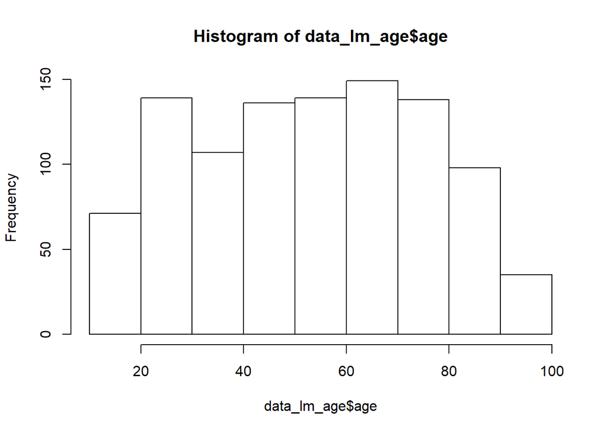

```r
# Not the first event

N_not_first_event <- nrow(data_full_cleaned%>%filter(SBB.1 > 1))
pct_not_first_event <- pct.fun(nrow(data_full_cleaned%>%filter(SBB.1 > 1)), nrow(data_full_cleaned%>%filter(!is.na(code.pat))))

# ANOVA on age:


data_lm_age <- data_full_cleaned%>%
  mutate(more_1_event = ifelse(SBB.1 > 1, "many", "one"))%>%
  mutate(dx_paste = ifelse(dx.event == "Epilepsy", paste(dx.event, type.epi.final),dx.event))%>%
  select(code.pat, age, dx.event, dx.epi,  more_1_event, dx_paste, genre, les.epi)

hist(data_lm_age$age)
```

```r
model_age <- lm(age ~  dx_paste + more_1_event + genre + les.epi, data = data_lm_age)
vif(model_age)
```

```
##                  GVIF Df GVIF^(1/(2*Df))
## dx_paste     2.362365  9        1.048918
## more_1_event 1.029384  1        1.014586
## genre        1.025161  1        1.012502
## les.epi      2.273053  4        1.108093
```

```r
temp <- data_full_cleaned%>%
  group_by(ATCD_specific)%>%
  summarise(N = n())%>%
  mutate( ATCD_specific = case_when(ATCD_specific == 'aucun' ~ 'No comorbidities',
                                    ATCD_specific == 'autres' ~ 'Other',
                                    ATCD_specific == 'cardiaque' ~ 'Cardiac',
                                    ATCD_specific == 'neurologique' ~ 'Neurologic',
                                    ATCD_specific == 'psychiatrique' ~ 'Psychiatric'))%>%
  filter(!is.na(ATCD_specific))%>%
  mutate(PCT = pct.fun_n(N, 777))%>%
  rename(`Relevant events in medical history` = ATCD_specific)

N_atcd_positive <- temp%>%filter(`Relevant events in medical history` != "No comorbidities")%>%summarize(sum(N))
N_atcd <- temp%>%summarize(sum(N))
```

In 7.41% (N = 75/1012) of the patients, the index event (both epileptic and non-epileptic) was not the first. As described above, the mean age of these was not significantly different from the true FS patients (F(1) = 0.61 p = 0.436). Table X summarizes the medical history which was positive in 56.76%.

| Relevant events in medical history | N | PCT |
| --- | --- | --- |
| No comorbidities | 336 | 43.24 |
| Other | 42 | 5.41 |
| Cardiac | 44 | 5.66 |
| Neurologic | 302 | 38.87 |
| Psychiatric | 53 | 6.82 |

*Table 3: description of the medical history of patients included in the study. This information was available only for 777 patients over the entire sample of 1012 patients.*

## Diagnoses

### Epilepsy

```r
# Chi2 frequency event sleep between epilepsy and non-epilepsy patients
data_chi <- data_full_cleaned%>%select(dx.general, veille.sommeil)%>%
  filter(veille.sommeil != "non documente")%>%
  mutate(dx.general = ifelse(dx.general == "Epileptic seizure", "epileptic seizure", "not epileptic event"))%>%
  group_by(dx.general, veille.sommeil)%>%
  summarise(N = n())%>%
  spread(key = veille.sommeil, N)

data_chi <- as.data.frame(data_chi)
row.names(data_chi) <- data_chi$dx_cat
data_chi <- data_chi[,2:3]

chi_sleep_wake <- chisq.test(data_chi)

# seizure occuring in sleep

sz_sleep <- data_full_cleaned%>%
  filter(veille.sommeil == "sommeil")%>%
  filter(dx.general == "Epileptic seizure") %>%
  summarise(N = n())

sz_sleep_epi <- data_full_cleaned%>%
  filter(veille.sommeil == "sommeil")%>%
  filter(!is.na(code.pat))%>%
  filter(dx.general == "Epileptic seizure") %>%
  filter(dx.event == "Epilepsy")%>%
  summarise(N = n())

# N per epilepsy types
N_epi_dx <- data_full_cleaned%>%
  group_by(dx.epi, type.epi.final)%>%
  summarise(N = n(),
            mean_age = mean(age, na.rm = T),
            sd_age = sd(age, na.rm = T))

tot_epi_disease <- nrow(data_full_cleaned%>%filter(dx.event == "Epilepsy"))

# % and N patients "operated" --> only the tumoral patients

N_pat_tumor <- data_full_cleaned%>%
  filter(type.epi.final == "lesionnelle")%>%
  filter(les.CT == "tumoral" | les.IRM == "tumoral")%>%
  summarise(N = n())

# post_hocs on the lm ANOVA investigating age differences among diagnoses
post_hoc_dx <- emmeans(model_age, list(pairwise ~ dx_paste), adjust = "tukey")
post_hoc_dx <- as.data.frame(post_hoc_dx$`pairwise differences of dx_paste`)
post_hoc <- report_emmeans(post_hoc_dx)
```

### Psychogenic origin

```r
N_epi_non_dx <- data_full_cleaned%>%
  group_by(dx.event)%>%
  summarise(N = n(),
            mean_age = round(mean(age, na.rm = T),2),
            sd_age = round(sd(age, na.rm = T),2))

# N men in the PNES group
post_hoc_gender_PNES <- emmeans(model_age, list(pairwise ~ genre|dx_paste), adjust = "tukey")
post_hoc_gender_PNES <- post_hoc_gender_PNES$`pairwise differences of genre | dx_paste`
post_hoc_gender_PNES <- as.data.frame(post_hoc_gender_PNES)

temp <- data_full_cleaned%>%
  filter(dx.event == "Psychogenic non epileptic seizure")%>%
  group_by(genre)%>%
  summarise(N = n())

N_H_psy <- temp$N[temp$genre == "H"]
N_psy <- sum(temp$N)
```

In 62 patients, seizures were of psychogenic origin (6.13% of the whole sample). These patients were significantly younger than those from the other groups (mean age: 38.89; SD = 17.45), i.e. the cardiac group (t(919) = 5.06; p <0.001), the cardiovascular group (t(919) = 6.15; p <0.001), SE (t(919) = 4.03; p = 0.002) and compared to the other diagnoses (t(919) = 4.06; p = 0.002). Even though women were significantly more likely to have psychogenic non-epileptic seizures (t(919) = 2.78; p = 0.005) compared to other non-epileptic diagnoses, men also presented psychogenic events (43.55%, N = 27/62).

### Cardiovascular origin

```r
ATCD <- data_full_cleaned%>%
  group_by(ATCD_specific)%>%
  summarise(N = n(),
            AGE = mean(age, na.rm = T),
            SD_AGE = sd(age, na.rm = T))%>%
  mutate(ATCD_specific = case_when(ATCD_specific == 'aucun' ~ 'No comorbidities',
                                    ATCD_specific == 'autres' ~ 'Other',
                                    ATCD_specific == 'cardiaque' ~ 'Cardiac',
                                    ATCD_specific == 'neurologique' ~ 'Neurologic',
                                    ATCD_specific == 'psychiatrique' ~ 'Psychiatric'))%>%
  filter(!is.na(ATCD_specific))%>%
  mutate(PCT = pct.fun_n(N,777))

temp <- data_full_cleaned%>%
  mutate(cat_age = ifelse(age < 60, '<60', '>60'))%>%
  filter(dx.event == "Cardiovascular")%>%
  group_by(cat_age)%>%
  summarise(N = n(),
    mean_age = round(mean(age, na.rm = T),2),
            sd_age = round(sd(age, na.rm = T),2))
  N_less_60 <- temp$N[temp$cat_age == "<60"]

# age range Cardiovascular

  age_range_cardio <- range(data_full_cleaned$age[data_full_cleaned$dx.event == "Cardiovascular"], na.rm = T)

# description types cardiovascular
types_cardiovasc <- data_full_cleaned%>%
  filter(dx.event == "Cardiovascular")%>%
  group_by(type.cardiovasculaire)%>%
  summarise(N = n())%>%
  mutate(type.cardiovasculaire = case_when(type.cardiovasculaire == "ACR" ~ "Cardiac arrest",
                   type.cardiovasculaire == "AIT" ~ "Transient ischemic attack",
                   type.cardiovasculaire == "AVC" ~ "Stroke",
                   type.cardiovasculaire == "multifactoriel" ~ "Multifactorial",
                   type.cardiovasculaire == "symptomes post-AVC" ~ "Post-stroke symptoms",
                   type.cardiovasculaire == "syncope" ~ "Syncope"))
```

Not surprisingly, patients (N= 102) were on average significantly older than the vasovagal and orthostatic syncope group (t(919) = 3.72; p = 0.008), the NLE group (t(919) = 3.59; p = 0.013), the IGE group (t(919) = 7.21; p <0.001), as well as the psychogenic group (t(919) = 6.15; p <0.001). In most of the patients (94.34%) of the patients, no prior cardiac problems were reported. The mean age of these patients was 61.79 (SD = 23.63), with 43.14% younger than 60 years (range: 18 to 99 years old).

| type.cardiovasculaire | N |
| --- | --- |
| Cardiac arrest | 1 |
| Transient ischemic attack | 20 |
| Stroke | 16 |
| Multifactorial | 1 |
| Post-stroke symptoms | 2 |
| Syncope | 62 |

*Table 4: description of the diagnosis embedded on the cardiovascular group of patients*

### Vaso-vagal and orthostatic syncopes

Overall, 3.75% of the patients in the total sample were diagnosed with non-cardiac syncopes. Predictably, they were significantly younger than those with cardiac syncopes (t(919) = 3.9; p = 0.004). Long post-syncope confusion, the notion of clonic or asymmetric movements, or certain comorbidities affecting the CNS required in-depth investigations.

## Diagnostic tools

### MRI - CT

```r
N_les <- data_full_cleaned%>%
  filter(res.IRM != "aucun", res.IRM != "aucun mais propose")%>%
  group_by(les.epi)%>%
  summarise(N = n())

N_normal <- N_les$N[N_les$les.epi == "normal"]+N_les$N[N_les$les.epi == "lesion non epileptogene"]

post_hoc_les <- emmeans(model_age, list(pairwise ~ les.epi), adjust = "tukey")
post_hoc_les <- as.data.frame(post_hoc_les$`pairwise differences of les.epi`)
post_hoc_les <- report_emmeans(post_hoc_les)

# Among epileptic patients

N_les_epi <- data_full_cleaned%>%
  filter(dx.event == "Epilepsy")%>%
  filter(res.IRM != "aucun", res.IRM != "aucun mais propose")%>%
  group_by(les.epi)%>%
  summarise(N = n())

N_normal_epi <- N_les_epi$N[N_les_epi$les.epi == "normal"]+N_les_epi$N[N_les_epi$les.epi == "lesion non epileptogene"]
```

Among all patients, 263 had a normal MRI or showed benign abnormalities (few small white matter lesions, developmental venous abnormalities, etc), while 59 epileptic patients showed normal or non-epileptogenic lesions. 69 of the 652 patients with an MRI (10.58%) belonged to the intermediate category. Among the epileptic patients, the proportion is relatively similar (10.54% or 35 of the 332 patients). Regarding age, patients with an epileptogenic lesion and intermediate lesion were significantly older than the patients without lesion (epileptogenic lesion: t(919) = 5.19; p <0.001; intermediate: t(919) = 5.73; p <0.001).

### Standard EEG

```r
# Epileptic abnormalities on the EEG

N_epi_spikes <- nrow(data_full_cleaned%>%
  filter(!is.na(code.pat))%>%
  filter(dx.event == "Epilepsy")%>%
  filter(EEG.result_resume == "pointes" |
         EEG.result_resume == "pointes+slow"))


N_epi_EEG <- nrow(data_full_cleaned%>%
  filter(!is.na(code.pat))%>%
  filter(dx.event == "Epilepsy")%>%
  filter(res.1st.EEG != "aucun" ,
         res.1st.EEG != "aucun mais propose"))

# Non-epileptic abnormalities on the EEG

N_non_epi_abn_EEG <- nrow(data_full_cleaned%>%
       filter(!is.na(code.pat))%>%
       filter(dx.event == "Epilepsy")%>%
       filter(EEG.result_resume == "slow"))


# Normal EEG among epileptic patients

N_epi_norm_EEG <- nrow(data_full_cleaned%>%
       filter(!is.na(code.pat))%>%
       filter(dx.event == "Epilepsy")%>%
       filter(res.1st.EEG == "normal"))


# Delay EEG

EEG_24 <- nrow(data_full_cleaned%>%
  mutate(eeg_delay = date.1st.EEG - date.1st.cs.su)%>%
  filter(eeg_delay < 2)%>%
  select(EEG.result_resume, eeg_delay, dx.final, type.epi.final))

EEG_24_48 <- nrow(data_full_cleaned%>%
  mutate(eeg_delay = date.1st.EEG - date.1st.cs.su)%>%
  filter(eeg_delay >= 2 & eeg_delay < 3)%>%
  select(EEG.result_resume, eeg_delay, dx.final, type.epi.final))

EEG_48_72 <- nrow(data_full_cleaned%>%
  mutate(eeg_delay = date.1st.EEG - date.1st.cs.su)%>%
  filter(eeg_delay >= 3 & eeg_delay < 4)%>%
  select(EEG.result_resume, eeg_delay, dx.final, type.epi.final))

EEG_more_72 <- nrow(data_full_cleaned%>%
  mutate(eeg_delay = date.1st.EEG - date.1st.cs.su)%>%
  filter(eeg_delay >= 4)%>%
  select(EEG.result_resume, eeg_delay, dx.final, type.epi.final))

N_tot_EEG_time <- nrow(data_full_cleaned[!is.na(data_full_cleaned$date.1st.cs.su) & !is.na(data_full_cleaned$date.1st.EEG),])

# Chi squares efficacy EEG delay all patients
data_chi <- data_full_cleaned%>%
  mutate(spikes.dicho = ifelse(EEG.result_resume == "pointes" | EEG.result_resume == "pointes+slow", "pointes", "pas_pointes"),
         spikes.dicho = ifelse(is.na(spikes.dicho), "pas_pointes", spikes.dicho),
         eeg_delay = as.numeric(date.1st.EEG - date.1st.cs.su),
         cat_delay = case_when(eeg_delay < 2 ~ "24h",
                               eeg_delay > 1 & eeg_delay < 3 ~ "48h",
                               eeg_delay > 2 & eeg_delay <4 ~ "72h",
                               eeg_delay >=4 ~ "+72h"))%>%
           group_by(cat_delay, spikes.dicho)%>%
  summarise(N = n())%>%
  spread(cat_delay, N)

rownames <- data_chi$EEG_delay_cat
data_chi <- data_chi[,2:ncol(data_chi)]
data_chi <- as.data.frame(data_chi, row.names =rownames)
data_chi <- as.data.frame(data_chi, row.names =rownames)

chi2_EEG_all <- chisq.test(data_chi, simulate.p.value = T)

# Chi squares efficacy EEG delay epileptic patients

data_chi <- data_full_cleaned%>%
  filter(dx.event == "Epilepsy")%>%
  mutate(spikes.dicho = ifelse(EEG.result_resume == "pointes" | EEG.result_resume == "pointes+slow", "pointes", "pas_pointes"),
         spikes.dicho = ifelse(is.na(spikes.dicho), "pas_pointes", spikes.dicho),
         eeg_delay = as.numeric(date.1st.EEG - date.1st.cs.su),
         cat_delay = case_when(eeg_delay < 2 ~ "24h",
                               eeg_delay > 1 & eeg_delay < 3 ~ "48h",
                               eeg_delay > 2 & eeg_delay <4 ~ "72h",
                               eeg_delay >=4 ~ "+72h"))%>%
           group_by(cat_delay, spikes.dicho)%>%
  summarise(N = n())%>%
  spread(cat_delay, N)

rownames <- data_chi$EEG_delay_cat
data_chi <- data_chi[,2:ncol(data_chi)]
data_chi <- as.data.frame(data_chi, row.names =rownames)
data_chi <- as.data.frame(data_chi, row.names =rownames)

chi2_EEG_epi <- chisq.test(data_chi, simulate.p.value = T)
```

In 121 epileptic patients (over 470 who underwent an EEG; 25.74%), the EEG showed epileptiform abnormalities, and in another 200 (42.55%) unspecific abnormalities were identified, leaving 149 (31.7%) with a completely normal EEG. While we aimed at carrying out the EEG within 24h, this was not always possible. Among all diagnoses, in 695 (76.46%) out of 909 patients for whom the timing information could be retrieved, the standard EEG was done within 24h. 5.94% (N = 54/909) of the EEG were realised between 24 and 48h, while 2.42% (N = 22/909) were done between 48h and 72h, and the reminder 15.18% (N = 138/909) after 72h. There was no difference in the occurrence of epileptiform or any abnormal finding between the different delays of the whole group (X2 = 8.2; p = 0.08) or of the group of epileptic patients taken separately (X2 = 7.29; p = 0.127).

```r
temp <- data_full_cleaned%>%filter(dx.event != "Epilepsy" | is.na(dx.event))%>%
  filter(EEG.result_resume == "pointes" | EEG.result_resume == "pointes+slow")%>%
  group_by(dx.general, dx.event, dx.epi)%>%
  summarise(N = n())

N_spikes_not_epi <- nrow(data_full_cleaned%>%
  filter(EEG.result_resume == "pointes" |
           EEG.result_resume == "pointes+slow")%>%
  filter(dx.event != "Epilepsy" & dx.event != "Acute symptomatic seizure" & dx.event != "Unknown")%>%
  select(code.pat, date.1st.cs.su, date.1st.EEG, res.1st.EEG, EEG.result_resume,  date.lt.EEG, res.lt.EEG, EEG.lt.result_resume, dx.final, type.epi.final, type.autre.final))

N_spikes_not_epi_lt_normal <- nrow(data_full_cleaned%>%
  filter(EEG.result_resume == "pointes" |
           EEG.result_resume == "pointes+slow")%>%
  filter(dx.event != "Epilepsy" & dx.event != "Acute symptomatic seizure" & dx.event != "Unknown")%>%
    filter(res.lt.EEG == "normal")%>%
  select(code.pat, date.1st.cs.su, date.1st.EEG, res.1st.EEG, EEG.result_resume,  date.lt.EEG, res.lt.EEG, EEG.lt.result_resume, dx.final, type.epi.final, type.autre.final))
```

Note: check corrections Pia

### Long-term EEG

```r
N_LT_EEG <- nrow(data_full_cleaned%>%
  filter(res.lt.EEG != "aucun" & res.lt.EEG != "aucun mais propose"))

N_spikes_LTEEG <- nrow(data_full_cleaned%>%
  filter(res.lt.EEG != "aucun" & res.lt.EEG != "aucun mais propose")%>%
    filter(EEG.lt.result_resume == "pointes" | EEG.lt.result_resume == "pointes+slow"))

N_spikes_LTEEG_epi <- nrow(data_full_cleaned%>%
  filter(res.lt.EEG != "aucun" & res.lt.EEG != "aucun mais propose")%>%
    filter(EEG.lt.result_resume == "pointes" | EEG.lt.result_resume == "pointes+slow")%>%
    filter(dx.event == "Epilepsy"))

spikes_non_epi <- data_full_cleaned%>%
  filter(EEG.lt.result_resume == "pointes" | EEG.lt.result_resume == "pointes+slow")%>%
  filter(dx.event != "Epilepsy")%>%
  group_by(dx.event)%>%
  summarise(N = n())

N_LT_EEG_norm_std <- nrow(data_full_cleaned%>%
       filter(!is.na(code.pat))%>%
       filter(dx.event == "Epilepsy")%>%
       filter(EEG.result_resume == "slow" | res.1st.EEG == "normal")%>%
         filter(res.lt.EEG != "aucun" & res.lt.EEG != "aucun mais propose"))

N_LT_EEG_norm_std_spikes <- nrow(data_full_cleaned%>%
       filter(!is.na(code.pat))%>%
       filter(dx.event == "Epilepsy")%>%
       filter(EEG.result_resume == "slow" | res.1st.EEG == "normal")%>%
         filter(res.lt.EEG != "aucun" & res.lt.EEG != "aucun mais propose")%>%
         filter(EEG.lt.result_resume == "pointes" | EEG.lt.result_resume == "pointes+slow"))
```

### Multimodal information

```r
# Patients with all 3 negative exams

N_pat_all_normal <- nrow(data_full_cleaned%>%
  filter(pointes.1st.EEG != "focale" & pointes.1st.EEG != "diffuse" & res.1st.EEG != "aucun" & res.1st.EEG != "aucun mais propose")%>%
   filter(pointes.lt.EEG != "focale" & pointes.lt.EEG != "diffuse" & res.lt.EEG != "aucun" & res.lt.EEG != "aucun mais propose")%>%
  filter(les.epi == "normal" | les.epi == "lesion non epileptogene")%>%
  filter(res.IRM != "aucun" & res.IRM != "aucun mais propose"))

N_pat_all_normal_suspicious_les <- nrow(data_full_cleaned%>%filter(res.1st.EEG != "aucun" & res.1st.EEG != "aucun mais propose")%>%
  filter(EEG.result_resume == "slow" | is.na(EEG.result_resume))%>%
  filter(res.lt.EEG != "aucun" & res.lt.EEG != "aucun mais propose")%>%
  filter(EEG.lt.result_resume == "slow" | is.na(EEG.lt.result_resume))%>%
  filter(res.IRM != "aucun" & res.IRM != "aucun mais propose")%>%
  filter(les.epi != "lesion epileptogene")%>%
  select(pointes.1st.EEG, pointes.lt.EEG, res.IRM, les.epi)%>%
  filter(les.epi == "douteux"))

# N patients epileptic among these patients
N_pat_all_normal_epi <- nrow(data_full_cleaned%>%
  filter(pointes.1st.EEG != "focale" & pointes.1st.EEG != "diffuse" & res.1st.EEG != "aucun" & res.1st.EEG != "aucun mais propose")%>%
  filter(pointes.lt.EEG != "focale" & pointes.lt.EEG != "diffuse" & res.lt.EEG != "aucun" & res.lt.EEG != "aucun mais propose")%>%
  filter(les.epi == "normal" | les.epi == "lesion non epileptogene")%>%
  filter(res.IRM != "aucun" & res.IRM != "aucun mais propose")%>%
  filter(dx.event == "Epilepsy"))

# Same but only with routine EEG and MRI
N_pat_all_normal_epi_lt_mri <- nrow(data_full_cleaned%>%
  filter(res.1st.EEG != "aucun" & res.1st.EEG != "aucun mais propose")%>%
  filter(pointes.lt.EEG != "focale" & pointes.lt.EEG != "diffuse" & res.lt.EEG != "aucun" & res.lt.EEG != "aucun mais propose")%>%
  filter(les.epi == "normal" | les.epi == "lesion non epileptogene")%>%
  filter(res.IRM != "aucun" & res.IRM != "aucun mais propose")%>%
  filter(dx.event == "Epilepsy"))
```

While routine EEG, MRI and LTM-EEG are the hallmark exams to diagnose epilepsy, we were wondering what the combined yield is. Among patients with all three negative exams (N = 76), seven patients were nevertheless diagnosed with epilepsy (9.21% without taking into account the 15 patients with intermediate lesions). If only MRI and long-term EEG are negative, this number rises to nine i.e. two patients (0.42% of the group of epileptic patients) would be incorrectly diagnosed as non-epileptic.

Note: Add a probability tree with the three exams to see probabilities among the different exams

```r
data_tree_exams <- data_full_cleaned%>%
  filter(res.IRM != "aucun" & res.IRM != "aucun mais propose")%>%
  filter(res.1st.EEG != "aucun" & res.1st.EEG != "aucun mais propose")%>%
  #filter(res.lt.EEG != "aucun" & res.lt.EEG != "aucun mais propose")%>%
  filter(les.epi != "douteux")%>%
  mutate(dx.dicho = ifelse(dx.event != "Epilepsy" | is.na(dx.event), "non-epileptic", "epileptic"),
         les.epi = ifelse(les.epi == "lesion epileptogene", "epileptogenic lesion", "no epileptogenic lesion"),
         EEG.result_resume = ifelse(is.na(EEG.result_resume) | EEG.result_resume == "slow", "no spikes", "spikes"),
         EEG.lt.result_resume = ifelse(is.na(EEG.lt.result_resume) | EEG.lt.result_resume == "slow", "no spikes", "spikes"))%>%
  mutate(EEG_LT_y_n <- ifelse(res.lt.EEG == "aucun" | res.lt.EEG == "aucun mais propose", "no", "yes"),
         to_remove = ifelse(EEG.result_resume == "no spikes" & EEG_LT_y_n == "no", "remove", "keep"))%>%
  filter(to_remove == "keep")%>%
  select(code.pat, dx.dicho, les.epi, EEG.result_resume, EEG.lt.result_resume, pointes.1st.EEG, pointes.lt.EEG, dx.event)


# Probability of being epileptic without any exam in the sample
data_tree_exams%>%
  group_by(dx.dicho)%>%
  summarise(N = n())
```

```
## # A tibble: 2 x 2
##   dx.dicho          N
##   <chr>         <int>
## 1 epileptic       138
## 2 non-epileptic   113
```

```r
# Probability of being epileptic according to epileptogenic lesion
data_tree_exams%>%
  group_by(les.epi,dx.dicho)%>%
  summarise(N = n())%>%
  filter(les.epi == "no epileptogenic lesion")
```

```
## # A tibble: 2 x 3
## # Groups:   les.epi [1]
##   les.epi                 dx.dicho          N
##   <chr>                   <chr>         <int>
## 1 no epileptogenic lesion epileptic        50
## 2 no epileptogenic lesion non-epileptic    87
```

```r
data_tree_exams%>%
  group_by(les.epi,dx.dicho)%>%
  summarise(N = n())%>%
  filter(les.epi == "epileptogenic lesion")
```

```
## # A tibble: 2 x 3
## # Groups:   les.epi [1]
##   les.epi              dx.dicho          N
##   <chr>                <chr>         <int>
## 1 epileptogenic lesion epileptic        88
## 2 epileptogenic lesion non-epileptic    26
```

```r
# Probability of being epileptic according to epileptogenic lesion and Std EEG
data_tree_exams%>%
  group_by(EEG.result_resume, les.epi,dx.dicho)%>%
  summarise(N = n())%>%
  filter(les.epi == "no epileptogenic lesion" & EEG.result_resume == "no spikes")
```

```
## # A tibble: 2 x 4
## # Groups:   EEG.result_resume, les.epi [1]
##   EEG.result_resume les.epi                 dx.dicho          N
##   <chr>             <chr>                   <chr>         <int>
## 1 no spikes         no epileptogenic lesion epileptic        26
## 2 no spikes         no epileptogenic lesion non-epileptic    72
```

```r
data_tree_exams%>%
  group_by(EEG.result_resume, les.epi,dx.dicho)%>%
  summarise(N = n())%>%
  filter(les.epi == "no epileptogenic lesion" & EEG.result_resume == "spikes")
```

```
## # A tibble: 2 x 4
## # Groups:   EEG.result_resume, les.epi [1]
##   EEG.result_resume les.epi                 dx.dicho          N
##   <chr>             <chr>                   <chr>         <int>
## 1 spikes            no epileptogenic lesion epileptic        24
## 2 spikes            no epileptogenic lesion non-epileptic    15
```

```r
data_tree_exams%>%
  group_by(EEG.result_resume, les.epi,dx.dicho)%>%
  summarise(N = n())%>%
  filter(les.epi == "epileptogenic lesion" & EEG.result_resume == "no spikes")
```

```
## # A tibble: 2 x 4
## # Groups:   EEG.result_resume, les.epi [1]
##   EEG.result_resume les.epi              dx.dicho          N
##   <chr>             <chr>                <chr>         <int>
## 1 no spikes         epileptogenic lesion epileptic        31
## 2 no spikes         epileptogenic lesion non-epileptic    23
```

```r
data_tree_exams%>%
  group_by(EEG.result_resume, les.epi,dx.dicho)%>%
  summarise(N = n())%>%
  filter(les.epi == "epileptogenic lesion" & EEG.result_resume == "spikes")
```

```
## # A tibble: 2 x 4
## # Groups:   EEG.result_resume, les.epi [1]
##   EEG.result_resume les.epi              dx.dicho          N
##   <chr>             <chr>                <chr>         <int>
## 1 spikes            epileptogenic lesion epileptic        57
## 2 spikes            epileptogenic lesion non-epileptic     3
```

```r
# Probability of being epileptic according to epileptogenic lesion, Std EEG and LT EEG

data_tree_exams%>%
  group_by(EEG.lt.result_resume, EEG.result_resume, les.epi,dx.dicho)%>%
  summarise(N = n())%>%
  filter(les.epi == "no epileptogenic lesion" & EEG.result_resume == "no spikes" & EEG.lt.result_resume == "no spikes")
```

```
## # A tibble: 2 x 5
## # Groups:   EEG.lt.result_resume, EEG.result_resume, les.epi [1]
##   EEG.lt.result_resume EEG.result_resume les.epi              dx.dicho         N
##   <chr>                <chr>             <chr>                <chr>        <int>
## 1 no spikes            no spikes         no epileptogenic le~ epileptic        7
## 2 no spikes            no spikes         no epileptogenic le~ non-epilept~    69
```

```r
data_tree_exams%>%
  group_by(EEG.lt.result_resume, EEG.result_resume, les.epi,dx.dicho)%>%
  summarise(N = n())%>%
  filter(les.epi == "no epileptogenic lesion" & EEG.result_resume == "no spikes" & EEG.lt.result_resume == "spikes")
```

```
## # A tibble: 2 x 5
## # Groups:   EEG.lt.result_resume, EEG.result_resume, les.epi [1]
##   EEG.lt.result_resume EEG.result_resume les.epi              dx.dicho         N
##   <chr>                <chr>             <chr>                <chr>        <int>
## 1 spikes               no spikes         no epileptogenic le~ epileptic       19
## 2 spikes               no spikes         no epileptogenic le~ non-epilept~     3
```

```r
data_tree_exams%>%
  group_by(EEG.lt.result_resume, EEG.result_resume, les.epi,dx.dicho)%>%
  summarise(N = n())%>%
  filter(les.epi == "epileptogenic lesion" & EEG.result_resume == "no spikes" & EEG.lt.result_resume == "no spikes")
```

```
## # A tibble: 2 x 5
## # Groups:   EEG.lt.result_resume, EEG.result_resume, les.epi [1]
##   EEG.lt.result_resume EEG.result_resume les.epi              dx.dicho         N
##   <chr>                <chr>             <chr>                <chr>        <int>
## 1 no spikes            no spikes         epileptogenic lesion epileptic       18
## 2 no spikes            no spikes         epileptogenic lesion non-epilept~    23
```

```r
data_tree_exams%>%
  group_by(EEG.lt.result_resume, EEG.result_resume, les.epi,dx.dicho)%>%
  summarise(N = n())%>%
  filter(les.epi == "epileptogenic lesion" & EEG.result_resume == "no spikes" & EEG.lt.result_resume == "spikes")
```

```
## # A tibble: 1 x 5
## # Groups:   EEG.lt.result_resume, EEG.result_resume, les.epi [1]
##   EEG.lt.result_resume EEG.result_resume les.epi              dx.dicho      N
##   <chr>                <chr>             <chr>                <chr>     <int>
## 1 spikes               no spikes         epileptogenic lesion epileptic    13
```